# EnsemblSummarisation

Nick Burns

14 June 2016

In GTEx_Online_Analysis_methods we showed that we could effectively summarise the data using mini-batch kmeans and still extract the strognest clustering structure from the data. Here we are going to explore this in more detail to see if it holds up on simulated datasets. We will focus on two-dimensional datasets, as these are easy to visualise.

```r
setwd("~/Documents/GitHub/GTExEDA/")
library(MASS)

# set.seed(101)
#
# simulate_cluster <- function (x_mu, y_mu, N, cov_m = matrix(c(1, 0.5, 0.5, 1), ncol = 2)) {
#     MASS::mvrnorm(n = N, mu = c(x_mu, y_mu), Sigma = cov_m * runif(4))
# }
# sim_2clusters <- rbind(simulate_cluster(1, 2, 100),
#                        simulate_cluster(5, -2, 500))
# sim_2clusters <- cbind(sim_2clusters, c(rep(1, 100), rep(2, 500)))
#
# sim_3clusters <- rbind(simulate_cluster(1, 3.5, 70),
#                        simulate_cluster(0, -2, 200),
#                        simulate_cluster(-2, 1, 150))
# sim_3clusters <- cbind(sim_3clusters, c(rep(1, 70), rep(2, 200), rep(3, 150)))
#
# sim_4clusters <- rbind(simulate_cluster(-1, -3, 40),
#                        simulate_cluster(-1, 2, 120),
#                        simulate_cluster(-2, 4, 110),
#                        simulate_cluster(4, 3, 80))
# sim_4clusters <- cbind(sim_4clusters, c(rep(1, 40), rep(2, 120), rep(3, 110), rep(4, 80)))
#
# sim_5clusters <- rbind(simulate_cluster(1, 10, 200),
#                        simulate_cluster(-1, -2, 200),
#                        simulate_cluster(6, 4, 50),
#                        simulate_cluster(3, 3, 230),
#                        simulate_cluster(1.5, -3, 100))
# sim_5clusters <- cbind(sim_5clusters, c(rep(1, 200), rep(2, 200), rep(3, 50), rep(4, 230), rep(5, 100)))
#
# par(mfrow = c(2, 2))
#
# plot(sim_2clusters, col = sim_2clusters[, 3])
# plot(sim_3clusters, col = sim_3clusters[, 3])
# plot(sim_4clusters, col = sim_4clusters[, 3])
# plot(sim_5clusters, col = sim_5clusters[, 3])
#
# par(mfrow = c(1, 1))
#
# sim_data <- list(sim2 = sim_2clusters, sim3 = sim_3clusters, sim4 = sim_4clusters, sim5 = sim_5clusters)
# save(sim_data, file = "simulated_clusters.Rdata")
load("simulated_clusters.Rdata")
```

Obviously, each of thse simulated datasets can be easily clustered - they aren’t large. But let’s pretend that they are we are going to do the following:

1. summarise each dataset using mini-btach kmeans
2. assign cluster labels to each summary set
3. train a KNN model on the summary set
4. use this KNN model to predict the cluster membership of the original datasets

```r
minibatch_kmeans <- function (data, l_batches, K) {
    batches <- sample(nrow(data)) %% l_batches
    print(table(batches))

    lcl_centroids <- NULL
    for (l in 0:(l_batches - 1)) {
        tmp <- data[batches == l, 1:2]
        cluster_model <- kmeans(tmp, K)
        print(table(cluster_model$cluster))
        lcl_centroids <- if (is.null(lcl_centroids)) as.data.frame(cluster_model$centers)
                         else rbind(lcl_centroids, as.data.frame(cluster_model$centers))
    }

    return (lcl_centroids)
}
elbow <- function (data, max_k = 10) {
    results <- lapply(1:max_k, function (k) {
        kmeans(data, k)$tot.withinss / nrow(data)
    })
    return (unlist(results))
}
cluster_centroids <- function (centroids, K) {
    centroids$cluster <- kmeans(centroids, K)$cluster
    return (centroids)
}
my_knn <- function (training, testing, N) {
    tmp <- kknn::train.kknn(factor(cluster) ~ ., data = training, ks = N)
    testing <- as.data.frame(testing[, 1:2])
    testing$cluster <- predict(tmp, testing)

    return (testing)
}
```

For sim2:

```r
centroids <- minibatch_kmeans(sim_data[["sim2"]], 10, 5)
```

```
## batches
##  0  1  2  3  4  5  6  7  8  9
## 60 60 60 60 60 60 60 60 60 60
##
##  1  2  3  4  5
##  7 20  5  8 20
##
##  1  2  3  4  5
## 22 12  5 14  7
##
##  1  2  3  4  5
## 13 16 12 11  8
##
##  1  2  3  4  5
## 14 21  7 12  6
##
##  1  2  3  4  5
##  6  5  3 22 24
##
##  1  2  3  4  5
## 10  9  2 20 19
##
##  1  2  3  4  5
## 12 16  7  8 17
##
##  1  2  3  4  5
##  2 13 19 11 15
##
##  1  2  3  4  5
## 11 13 14 19  3
##
##  1  2  3  4  5
## 13  3 23 10 11
```

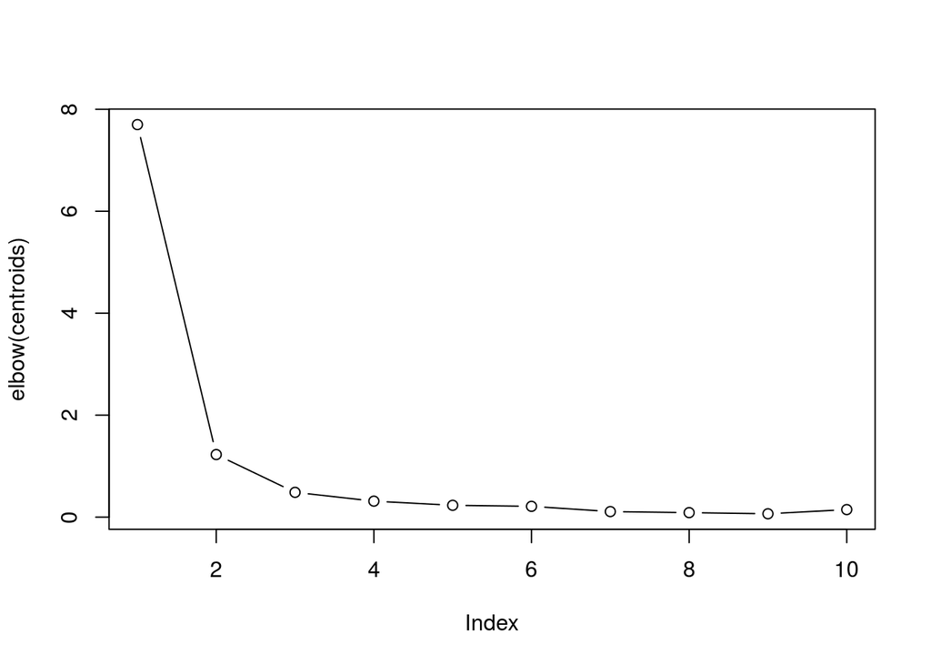

```r
plot(elbow(centroids), type = "b")
centroids <- cluster_centroids(centroids, 2)
result <- my_knn(centroids, sim_data[["sim2"]], 10)
```

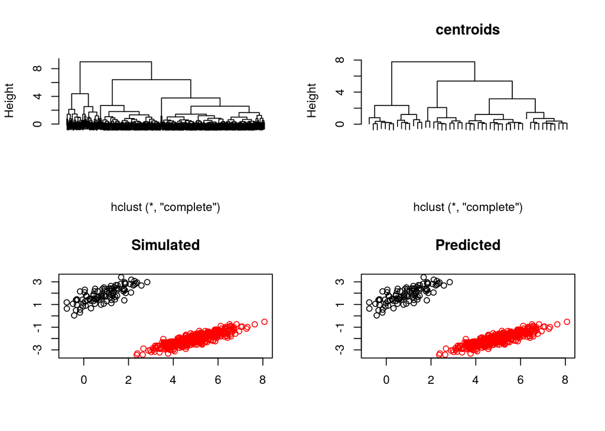

```r
par(mfrow = c(2, 2))
plot(hclust(dist(sim_data[["sim2"]][, 1:2])), main = NA, xlab = NA, labels = FALSE)
plot(hclust(dist(centroids[, 1:2])), main = "centroids", xlab = NA, labels = FALSE)

plot(sim_data[["sim2"]][, 1:2], col = sim_data[["sim2"]][, 3], xlab = NA, ylab = NA, main = "Simulated")
plot(result[, 1:2],col = result[, 3], xlab = NA, ylab = NA, main = "Predicted")
```

```r
par(mfrow = c(1, 1))

table(sim_data[["sim2"]][, 3], result$cluster)
```

```
##
##       1   2
##   1 100   0
##   2   0 500
```

For sim3:

```r
centroids <- minibatch_kmeans(sim_data[["sim3"]], 10, 5)
```

```
## batches
##  0  1  2  3  4  5  6  7  8  9
## 42 42 42 42 42 42 42 42 42 42
##
##  1  2  3  4  5
##  9  5 14  6  8
##
##  1  2  3  4  5
##  1 12 15  9  5
##
##  1  2  3  4  5
##  8  8 12  8  6
##
##  1  2  3  4  5
## 21  7 10  2  2
##
##  1  2  3  4  5
##  2  3 13 16  8
##
##  1  2  3  4  5
##  9  7 12 11  3
##
##  1  2  3  4  5
## 14  8  8  7  5
##
##  1  2  3  4  5
## 10  5  5 11 11
##
##  1  2  3  4  5
## 14  8  8 10  2
##
##  1  2  3  4  5
## 20 11  5  2  4
```

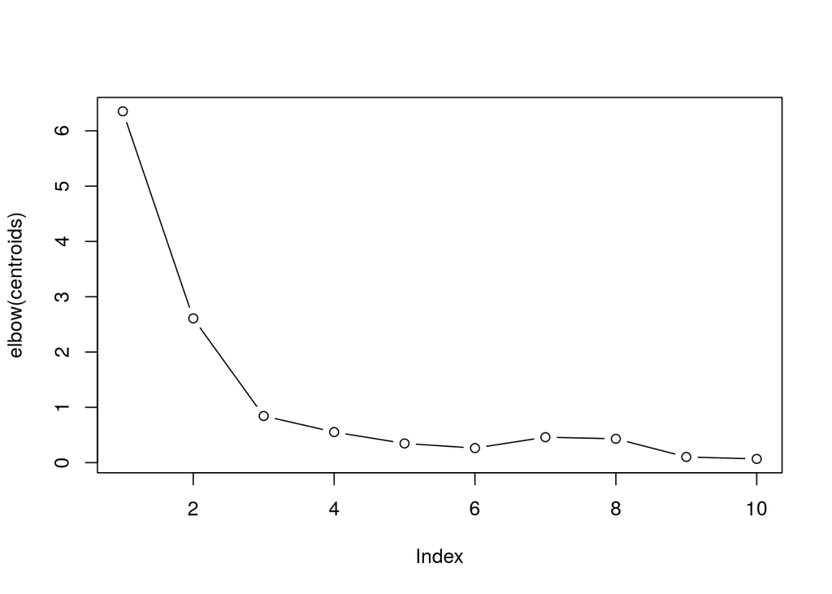

```r
plot(elbow(centroids), type = "b")
```

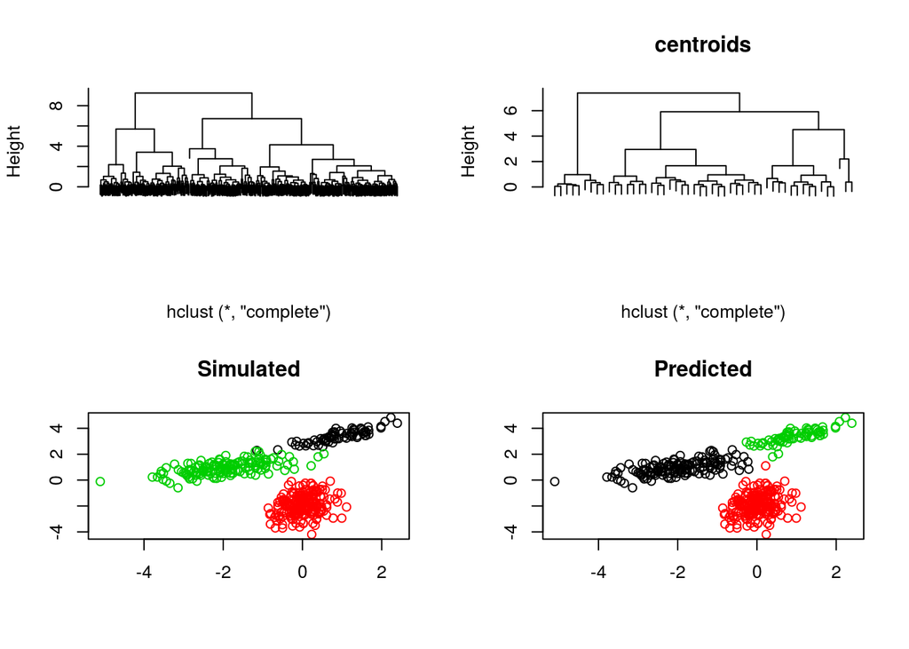

```r
centroids <- cluster_centroids(centroids, 3)
result <- my_knn(centroids, sim_data[["sim3"]], 5)

par(mfrow = c(2, 2))
plot(hclust(dist(sim_data[["sim3"]][, 1:2])), main = NA, xlab = NA, labels = FALSE)
plot(hclust(dist(centroids[, 1:2])), main = "centroids", xlab = NA, labels = FALSE)

plot(sim_data[["sim3"]][, 1:2], col = sim_data[["sim3"]][, 3], xlab = NA, ylab = NA, main = "Simulated")
plot(result[, 1:2],col = result[, 3], xlab = NA, ylab = NA, main = "Predicted")
```

```r
par(mfrow = c(1, 1))

table(sim_data[["sim3"]][, 3], result$cluster)
```

```
##
##       1   2   3
##   1   2   0  68
##   2   0 200   0
##   3 147   1   2
```

For sim4:

```r
centroids <- minibatch_kmeans(sim_data[["sim4"]], 10, 5)
```

```
## batches
##  0  1  2  3  4  5  6  7  8  9
## 35 35 35 35 35 35 35 35 35 35
##
##  1  2  3  4  5
##  5  6  5 14  5
##
##  1  2  3  4  5
##  2  9  8 11  5
##
## 1 2 3 4 5
## 5 8 5 8 9
##
##  1  2  3  4  5
##  9 13  1 11  1
##
##  1  2  3  4  5
##  8 15  8  3  1
##
## 1 2 3 4 5
## 7 9 8 7 4
##
##  1  2  3  4  5
##  8  6  8  3 10
##
## 1 2 3 4 5
## 8 4 8 6 9
##
##  1  2  3  4  5
##  7  6  3  7 12
##
##  1  2  3  4  5
##  3 10 10 10  2
```

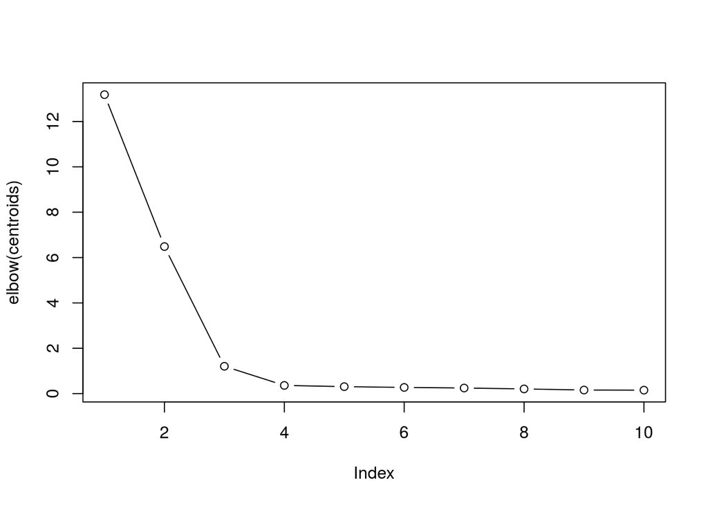

```r
plot(elbow(centroids), type = "b")
```

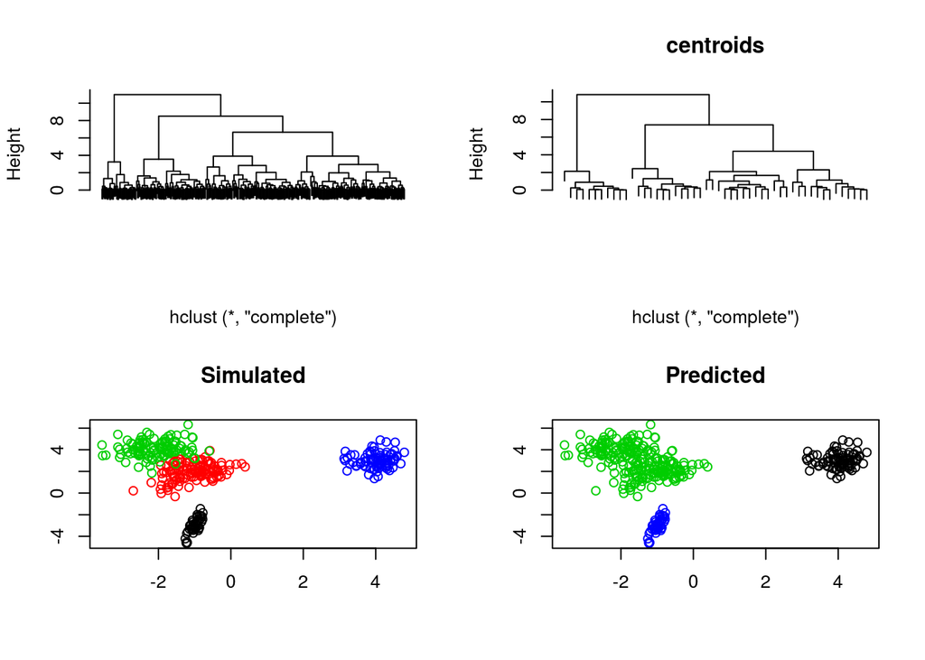

```r
centroids <- cluster_centroids(centroids, 4)
result <- my_knn(centroids, sim_data[["sim4"]], 5)

par(mfrow = c(2, 2))
plot(hclust(dist(sim_data[["sim4"]][, 1:2])), main = NA, xlab = NA, labels = FALSE)
plot(hclust(dist(centroids[, 1:2])), main = "centroids", xlab = NA, labels = FALSE)

plot(sim_data[["sim4"]][, 1:2], col = sim_data[["sim4"]][, 3], xlab = NA, ylab = NA, main = "Simulated")
plot(result[, 1:2],col = result[, 3], xlab = NA, ylab = NA, main = "Predicted")
```

```r
par(mfrow = c(1, 1))

table(sim_data[["sim4"]][, 3], result$cluster)
```

```
##
##       1   2   3   4
##   1   0   0   0  40
##   2   0   0 120   0
##   3   0   0 110   0
##   4  80   0   0   0
```

For sim5:

```r
centroids <- minibatch_kmeans(sim_data[["sim5"]], 10, 5)
```

```
## batches
##  0  1  2  3  4  5  6  7  8  9
## 78 78 78 78 78 78 78 78 78 78
##
##  1  2  3  4  5
##  7  9 35 22  5
##
##  1  2  3  4  5
##  2 17 31  7 21
##
##  1  2  3  4  5
## 22  8 14 19 15
##
##  1  2  3  4  5
##  8 15 38  7 10
##
##  1  2  3  4  5
##  7  6 11 27 27
##
##  1  2  3  4  5
## 13 13 20 20 12
##
##  1  2  3  4  5
##  5 13 10 21 29
##
##  1  2  3  4  5
## 13  9 16 20 20
##
##  1  2  3  4  5
##  7 11 23  8 29
##
##  1  2  3  4  5
##  7  3  6  4 58
```

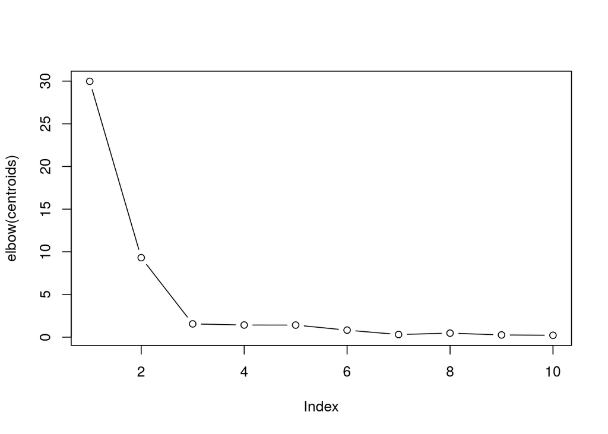

```r
plot(elbow(centroids), type = "b")
```

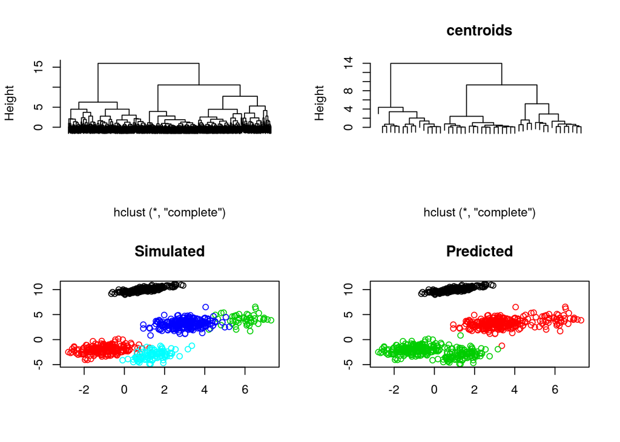

```r
centroids <- cluster_centroids(centroids, 3)
result <- my_knn(centroids, sim_data[["sim5"]], 5)

par(mfrow = c(2, 2))
plot(hclust(dist(sim_data[["sim5"]][, 1:2])), main = NA, xlab = NA, labels = FALSE)
plot(hclust(dist(centroids[, 1:2])), main = "centroids", xlab = NA, labels = FALSE)

plot(sim_data[["sim5"]][, 1:2], col = sim_data[["sim5"]][, 3], xlab = NA, ylab = NA, main = "Simulated")
plot(result[, 1:2],col = result[, 3], xlab = NA, ylab = NA, main = "Predicted")
```

```r
par(mfrow = c(1, 1))

table(sim_data[["sim5"]][, 3], result$cluster)
```

```
##
##       1   2   3
##   1 200   0   0
##   2   0   0 200
##   3   0  50   0
##   4   0 229   1
##   5   0   1  99
```

Finally, just to prove this one way or another, the Creighton set:

```r
library(data.table)
expression <- read.table("~/Google Drive/Projects/ICAPlaypen/GSE24185_series_matrix.txt", sep = "", comment.char = "!", header = TRUE, row.names = 1)
gene_names <- rownames(expression)
expression <- data.table(expression)

# filter to obesity-related genes
obesity_genes <- readLines('~/Google Drive/Projects/ICAPlaypen/crobsgenes.txt')
probes <- as.vector(na.omit(match(obesity_genes, gene_names)))
expression <- as.matrix(expression[probes])   # note probes is a vector of row indices.

# standardise (z-scores of gene expression)
expression <- apply(expression, 1, function (x) (x - mean(x)) / sd(x))
expression[expression < -3] <- 3
expression[expression > 3] <- 3
expression <- t(expression)

# a quick look
rownames(expression) <- gene_names[probes]
dim(expression)
```

```
## [1] 799 103
```

```r
head(expression[, 1:10])
```

```
##               GSM594855  GSM594856  GSM594857  GSM594858   GSM594859
## 217038_at   -2.64682053 -1.1201851 -0.2906172  0.8039515  0.33731958
## 205048_s_at -0.87034383  0.9641049  0.3121933 -1.2266211  0.03930015
## 218202_x_at -1.47779494 -1.1756354 -2.4409285 -0.1464044 -0.30692664
## 206462_s_at -1.61266881 -2.5611705 -1.1442729  1.6543924 -0.26603067
## 216861_at   -0.08492822 -1.5465819  0.5175855  0.3390629 -0.04029757
## 214014_at   -0.64691700 -0.1725112 -0.9056838  0.4851877  0.57144335
##              GSM594860  GSM594861    GSM594862  GSM594863  GSM594864
## 217038_at   -0.6132270  0.8154733 -2.105297033  1.0747133 -0.2963781
## 205048_s_at  1.4795698  0.9716852  1.881329212 -0.9158260  1.1308729
## 218202_x_at -0.3069266 -0.5996437 -0.609086202  0.1179852  0.3823749
## 206462_s_at  0.6356314  0.6941809 -1.518989637  1.6192627 -0.4650989
## 216861_at    0.7295811 -0.4308157 -0.006824589  0.5622162  3.0000000
## 214014_at   -1.6065105 -1.0674130  0.194075099 -0.2587668  0.3450224
```

And the run:

```r
centroids <- minibatch_kmeans(expression, 10, 5)
```

```
## batches
##  0  1  2  3  4  5  6  7  8  9
## 79 80 80 80 80 80 80 80 80 80
##
##  1  2  3  4  5
## 22  8  9 12 28
##
##  1  2  3  4  5
## 27 11 16 20  6
##
##  1  2  3  4  5
## 19  8 13 16 24
##
##  1  2  3  4  5
##  4 26 16 15 19
##
##  1  2  3  4  5
##  4 22 17  6 31
##
##  1  2  3  4  5
## 25 18  9 19  9
##
##  1  2  3  4  5
## 12 29 26 10  3
##
##  1  2  3  4  5
## 27 18  5 21  9
##
##  1  2  3  4  5
## 17 26 15  7 15
##
##  1  2  3  4  5
##  9  9 11 22 29
```

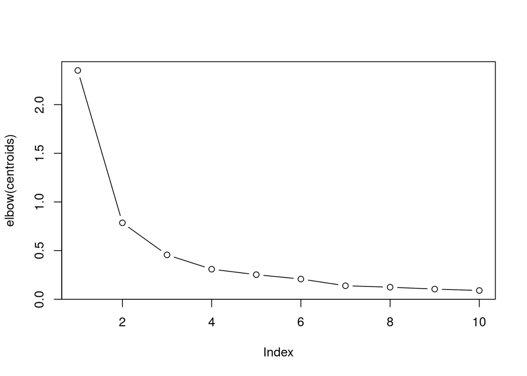

```r
plot(elbow(centroids), type = "b")
```

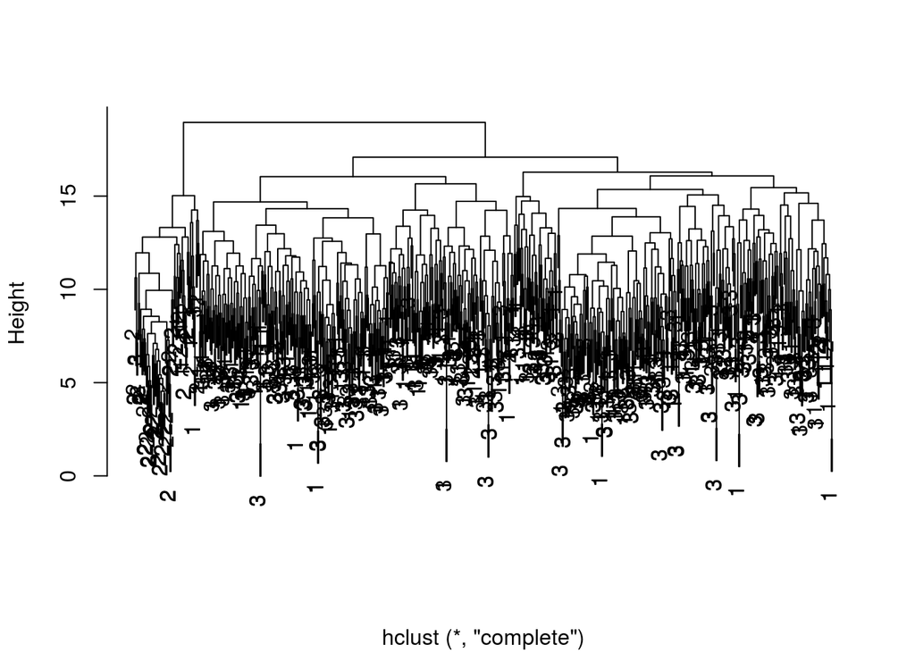

```r
centroids <- cluster_centroids(centroids, 3)
result <- my_knn(centroids, expression, 5)

plot(hclust(dist(expression)), main = NA, xlab = NA, labels = result$cluster)
```

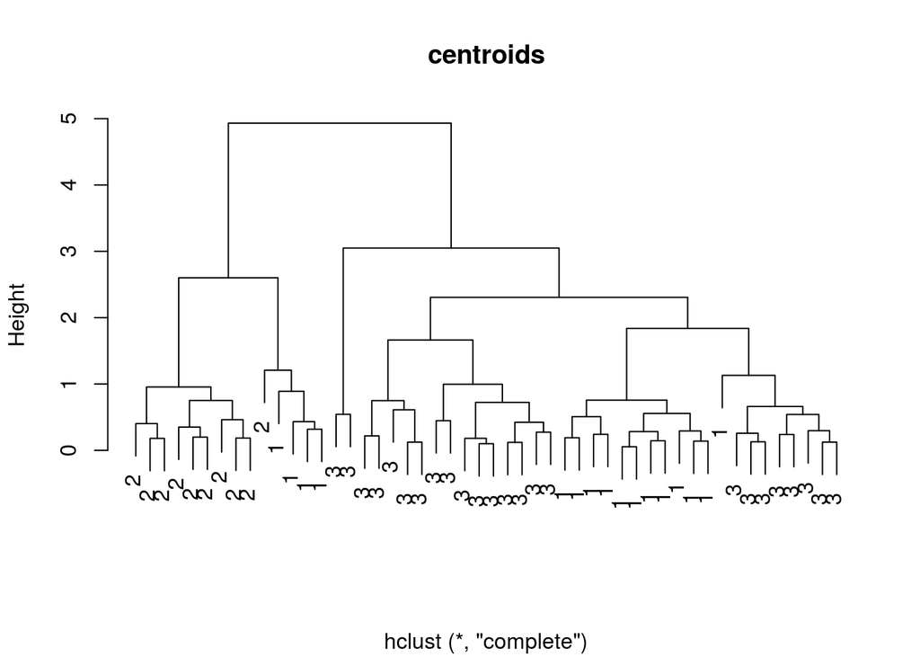

```r
plot(hclust(dist(centroids[, -ncol(centroids)])), main = "centroids", xlab = NA, labels = centroids$cluster)
```

My interpretation of this is that there are really only two clusters - and I am happy that the centroid dendrogram is a reasonable summary of the top one.